# 符号表达式的递归函数及其机器计算，第一部分

# Recursive Functions of Symbolic Expressions and Their Computation by Machine, Part I

约翰·麦卡锡，麻省理工学院，美国马萨诸塞州剑桥市。*

John McCarthy, Massachusetts Institute of Technology, Cambridge, Mass. ∗

1960 年 4 月

April 1960

## 1 引言

## 1 Introduction

麻省理工学院人工智能小组为 IBM 704 计算机开发了一套称为 LISP（LISt Processor，表处理器）的编程系统。这套系统旨在便于开展与拟议中的 Advice Taker（建议接受者）系统有关的实验。在该系统中，人们可以指示机器处理陈述句和命令句，并使机器在执行指令时表现出“常识”。Advice Taker 的最初提案 [1] 于 1958 年 11 月提出。主要需求是一套能够操作表达式的编程系统；这些表达式表示形式化的陈述句和命令句，从而使 Advice Taker 能够进行演绎。

A programming system called LISP (for LISt Processor) has been developed for the IBM 704 computer by the Artificial Intelligence group at M.I.T. The system was designed to facilitate experiments with a proposed system called the Advice Taker, whereby a machine could be instructed to handle declarative as well as imperative sentences and could exhibit “common sense” in carrying out its instructions. The original proposal [1] for the Advice Taker was made in November 1958. The main requirement was a programming system for manipulating expressions representing formalized declarative and imperative sentences so that the Advice Taker system could make deductions.

在开发过程中，LISP 系统经历了几个简化阶段，最终建立在一种方案之上，用来表示某类符号表达式上的偏递归函数。这种表示独立于 IBM 704，也独立于任何其他电子计算机。因此，现在看来，从称为 S 表达式的一类表达式和称为 S 函数的函数出发，来阐述这套系统是合适的。

In the course of its development the LISP system went through several stages of simplification and eventually came to be based on a scheme for representing the partial recursive functions of a certain class of symbolic expressions. This representation is independent of the IBM 704 computer, or of any other electronic computer, and it now seems expedient to expound the system by starting with the class of expressions called S-expressions and the functions called S-functions.

本文首先介绍一种递归定义函数的形式体系。我们认为，这种形式体系无论作为编程语言，还是作为发展计算理论的工具，都具有优势。接着介绍 S 表达式和 S 函数，给出一些例子，然后介绍通用 S 函数 apply。它在理论上起着通用图灵机的作用，在实践中起着解释器的作用。随后介绍如何在 IBM 704 的内存中，利用类似于 Newell、Shaw 和 Simon [2] 所用的表结构来表示 S 表达式，以及如何用程序表示 S 函数。然后说明 IBM 704 上 LISP 编程系统的主要特征。接下来给出另一种描述符号表达式计算的方法，最后给出流程图的递归函数解释。

In this article, we first describe a formalism for defining functions recursively. We believe this formalism has advantages both as a programming language and as a vehicle for developing a theory of computation. Next, we describe S-expressions and S-functions, give some examples, and then describe the universal S-function apply which plays the theoretical role of a universal Turing machine and the practical role of an interpreter. Then we describe the representation of S-expressions in the memory of the IBM 704 by list structures similar to those used by Newell, Shaw and Simon [2], and the representation of S-functions by program. Then we mention the main features of the LISP programming system for the IBM 704. Next comes another way of describing computations with symbolic expressions, and finally we give a recursive function interpretation of flow charts.

我们希望在另一篇论文中介绍 LISP 已经用于哪些符号计算，并在其他地方介绍这种递归函数形式体系在数理逻辑和机械定理证明问题中的一些应用。

We hope to describe some of the symbolic computations for which LISP has been used in another paper, and also to give elsewhere some applications of our recursive function formalism to mathematical logic and to the problem of mechanical theorem proving.

## 2 函数与函数定义

## 2 Functions and Function Definitions

我们需要用到一些关于一般函数的数学概念和记法。其中大多数概念已广为人知，但条件表达式的概念被认为是新的<sup>1</sup>；使用条件表达式，可以用一种新的、方便的方式递归地定义函数。

We shall need a number of mathematical ideas and notations concerning functions in general. Most of the ideas are well known, but the notion of conditional expression is believed to be new1, and the use of conditional expressions permits functions to be defined recursively in a new and convenient way.

### a. 偏函数

### a. Partial Functions

偏函数是只在其定义域的一部分上有定义的函数。当函数由计算来定义时，偏函数必然会出现，因为对于某些实参值，定义函数值的计算可能不会终止。不过，我们的一些初等函数也将被直接定义为偏函数。

A partial function is a function that is defined only on part of its domain. Partial functions necessarily arise when functions are defined by computations because for some values of the arguments the computation defining the value of the function may not terminate. However, some of our elementary functions will be defined as partial functions.

### b. 命题表达式与谓词

### b. Propositional Expressions and Predicates

命题表达式的可能值为 T（真）和 F（假）。我们假定读者熟悉命题联结词 ∧（“与”）、∨（“或”）和 ¬（“非”）。典型的命题表达式有：

A propositional expression is an expression whose possible values are T (for truth) and F (for falsity). We shall assume that the reader is familiar with the propositional connectives ∧ (“and”), ∨(“or”), and ¬ (“not”). Typical propositional expressions are:

$x<y(x<y)∧(b=c)$

x<y(x<y)∧(b=c)

x 是素数。

x is prime

谓词是值域由真值 T 和 F 构成的函数。

A predicate is a function whose range consists of the truth values T and F.

### c. 条件表达式

### c. Conditional Expressions

数学中，真值对其他类型量的依赖关系由谓词表达，真值对其他真值的依赖关系则由逻辑联结词表达。然而，用符号表示其他类型量对真值的依赖关系的记法并不充分。因此，即使文章对其他依赖关系使用符号描述，对这类依赖关系仍通常使用英语词语和短语来表达。例如，函数 |x| 通常用文字定义。条件表达式是一种表达量对命题量的依赖关系的工具。条件表达式具有如下形式：

The dependence of truth values on the values of quantities of other kinds is expressed in mathematics by predicates, and the dependence of truth values on other truth values by logical connectives. However, the notations for expressing symbolically the dependence of quantities of other kinds on truth values is inadequate, so that English words and phrases are generally used for expressing these dependences in texts that describe other dependences symbolically. For example, the function |x| is usually defined in words. Conditional expressions are a device for expressing the dependence of quantities on propositional quantities. A conditional expression has the form

$(p1→e1,···,pn→en)$

其中，各个 p 是命题表达式，各个 e 可以是任意类型的表达式。它可以读作：“如果 p₁，则 e₁；否则如果 p₂，则 e₂；……；否则如果 pₙ，则 eₙ”，或者“p₁ 产生 e₁，……，pₙ 产生 eₙ”。<sup>2</sup>

where the p’s are propositional expressions and the e’s are expressions of any kind. It may be read, “If p<sub>1</sub> then e<sub>1</sub> otherwise if p<sub>2</sub> then e<sub>2</sub>, · · · , otherwise if p<sub>n</sub> then e<sub>n</sub>,” or “p<sub>1</sub> yields e<sub>1</sub>, · · · , p<sub>n</sub> yields e<sub>n</sub>.” 2

下面给出规则，确定下列条件表达式的值是否有定义；若有定义，还要确定其值：

We now give the rules for determining whether the value of

$(p1→e1,···,pn→en)$

从左到右检查各个 p。如果在遇到任何值未定义的 p 之前，遇到了值为 T 的 p，那么条件表达式的值就是相应 e 的值，前提是该 e 有定义。如果在遇到为真的 p 之前遇到了未定义的 p，或者所有 p 都为假，或者第一个为真的 p 所对应的 e 未定义，那么条件表达式的值就是未定义的。下面给出一些例子。

is defined, and if so what its value is. Examine the p’s from left to right. If a p whose value is T is encountered before any p whose value is undefined is encountered then the value of the conditional expression is the value of the corresponding e (if this is defined). If any undefined p is encountered before a true p, or if all p’s are false, or if the e corresponding to the first true p is undefined, then the value of the conditional expression is undefined. We now give examples.

$(1<2→4,1>2→3)=4(2<1→4,2>1→3,2>1→2)=3(2<1→4,T→3)=3$

(1<2→4,1>2→3)=4(2<1→4,2>1→3,2>1→2)=3(2<1→4,T→3)=3

$(2<1→00,T→3)=3$

$(2<1→3,T→00)$

未定义。

is undefined

$(2<1→3,4<1→4)$

(2<1→3,4<1→4)isundeﬁned

未定义。

is undefined

条件表达式的一些最简单的应用，是给出如下定义：

Some of the simplest applications of conditional expressions are in giving such definitions as

$|x|=(x<0→−x,T→x)δij=(i=j→1,T→0)sgn(x)=(x<0→−1,x=0→0,T→1)$

|x|=(x<0→−x,T→x)δ=(i=j→1,T→0)ijsgn(x)=(x<0→−1,x=0→0,T→1)

### d. 递归函数定义

### d. Recursive Function Definitions

利用条件表达式，我们可以用包含被定义函数本身的公式来定义函数，而不产生循环论证。例如，我们写：

By using conditional expressions we can, without circularity, define functions by formulas in which the defined function occurs. For example, we write

$n!=(n=0→1,T→n·(n−1)!)$

n!=(n=0→1,T→n·(n−1)!)

用这个公式计算 0!，会得到答案 1；由于条件表达式的值采用了上述定义方式，无意义的表达式 0 · (0 − 1)! 不会出现。根据这个定义，2! 的计算过程如下：

When we use this formula to evaluate 0! we get the answer 1; because of the way in which the value of a conditional expression was defined, the meaningless expression 0 · (0 - 1)! does not arise. The evaluation of 2! according to this definition proceeds as follows:

$2!=(2=0→1,T→2·(2−1)!)=2·1!=2·(1=0→1T→·(1−1)!)=2·1·0!=2·1·(0=0→1,T→0·(0−1)!)=2·1·1=2$

2!=(2=0→1,T→2·(2−1)!)=2·1!=2·(1=0→1T→·(1−1)!)=2·1·0!=2·1·(0=0→1,T→0·(0−1)!)=2·1·1=2

下面再给出递归函数定义的两个应用。两个正整数 m 和 n 的最大公约数 gcd(m,n)，可以用欧几里得算法计算。该算法可表示为如下递归函数定义：

We now give two other applications of recursive function definitions. The greatest common divisor, gcd(m,n), of two positive integers m and n is computed by means of the Euclidean algorithm. This algorithm is expressed by the recursive function definition:

$gcd(m,n)=(m>n→gcd(n,m),rem(n,m)=0→m,T→gcd(rem(n,m),m))$

gcd(m,n)=(m>n→gcd(n,m),rem(n,m)=0→m,T→gcd(rem(n,m),m))

其中 rem(n,m) 表示 n 除以 m 所得的余数。

where rem(n, m) denotes the remainder left when n is divided by m.

求数 a 的近似平方根的牛顿算法，从初始近似值 x 出发，并要求可接受的近似值 y 满足 |y² − a| < ε，可以写为：

The Newtonian algorithm for obtaining an approximate square root of a number a, starting with an initial approximation x and requiring that an acceptable approximation y satisfy |y² −a| < ε, may be written as

$sqrt(a,x,ε)=(|x2−a|<ε→x,T→sqrt(a,12(x+ax),ε))$

也可以同时递归定义多个函数；在需要时，我们将使用这种定义。

The simultaneous recursive definition of several functions is also possible, and we shall use such definitions if they are required.

由递归定义所确定的计算，并不能保证最终会终止。例如，按我们的定义计算 n!，只有当 n 是非负整数时才会成功。如果计算不终止，就必须认为该函数对给定实参未定义。

There is no guarantee that the computation determined by a recursive definition will ever terminate and, for example, an attempt to compute n! from our definition will only succeed if n is a non-negative integer. If the computation does not terminate, the function must be regarded as undefined for the given arguments.

命题联结词本身也可以用条件表达式定义。我们写：

The propositional connectives themselves can be defined by conditional expressions. We write

$p∧q=(p→q,T→F)p∨q=(p→T,T→q)¬p=(p→F,T→T)p⊃q=(p→q,T→T)$

p∧q=(p→q,T→F)p∨q=(p→T,T→q)¬p=(p→F,T→T)p⊃q=(p→q,T→T)

容易看出，这些等式右端具有正确的真值表。如果考虑 p 或 q 可能未定义的情形，就会发现联结词 ∧ 和 ∨ 不满足交换律。例如，如果 p 为假而 q 未定义，根据上述定义，p ∧ q 为假，但 q ∧ p 未定义。对于我们的应用，这种非交换性是可取的，因为计算 p ∧ q 时先计算 p；若 p 为假，就不计算 q。如果 p 的计算不终止，我们也就永远不会开始计算 q。下文都将在这一意义上使用命题联结词。

It is readily seen that the right-hand sides of the equations have the correct truth tables. If we consider situations in which p or q may be undefined, the connectives ∧and ∨are seen to be noncommutative. For example if p is false and q is undefined, we see that according to the definitions given above p ∧q is false, but q ∧p is undefined. For our applications this noncommutativity is desirable, since p∧q is computed by first computing p, and if p is false q is not computed. If the computation for p does not terminate, we never get around to computing q. We shall use propositional connectives in this sense hereafter.

### e. 函数与形式

### e. Functions and Forms

在数学中，数理逻辑以外的领域通常并不严格使用“函数”一词，而把 y² + x 之类的形式也称为函数。由于后面我们要对表示函数的表达式进行计算，因此需要区分函数与形式，并用一种记法表达这种区别。Church [3] 给出了这种区分及其描述记法，我们的记法与之只有细微差别。

It is usual in mathematics—outside of mathematical logic—to use the word “function” imprecisely and to apply it to forms such as y² + x. Because we shall later compute with expressions for functions, we need a distinction between functions and forms and a notation for expressing this distinction. This distinction and a notation for describing it, from which we deviate trivially, is given by Church [3].

设 f 是表示两个整数变量的函数的表达式。那么写 f(3,4) 应当有意义，而且该表达式的值应当确定。表达式 y² + x 不满足这一要求；y² + x(3,4) 不是惯用记法，如果试图定义它，我们也无法确定其值应为 13 还是 19。Church 把 y² + x 这样的表达式称为形式。如果能确定形式中出现的变量，与所需函数的有序实参列表之间的对应关系，就能把形式转变为函数。这由 Church 的 λ 记法来实现。

Let f be an expression that stands for a function of two integer variables. It should make sense to write f(3, 4) and the value of this expression should be determined. The expression y²+x does not meet this requirement; y²+x(3, 4) is not a conventional notation, and if we attempted to define it we would be uncertain whether its value would turn out to be 13 or 19. Church calls an expression like y² + x, a form. A form can be converted into a function if we can determine the correspondence between the variables occurring in the form and the ordered list of arguments of the desired function. This is accomplished by Church’s λ-notation.

若 E 是变量 x₁，……，xₙ 的一个形式，则 λ((x₁，……，xₙ),E) 表示一个 n 元函数。它的值通过按顺序将实参代入 E 中的 x₁，……，xₙ，再对所得表达式求值来确定。例如，λ((x,y),y² + x) 是二元函数，而且 λ((x,y),y² + x)(3,4) = 19。

If E is a form in variables x<sub>1</sub>, · · ·, x<sub>n</sub>, then λ((x<sub>1</sub>, · · · , x<sub>n</sub>), E) will be taken to be the function of n variables whose value is determined by substituting the arguments for the variables x<sub>1</sub>, · · · , x<sub>n</sub> in that order in E and evaluating the resulting expression. For example, λ((x, y), y² + x) is a function of two variables, and λ((x, y), y² + x)(3, 4) = 19.

λ 表达式变量列表中的变量是哑变量或约束变量，类似于定积分中的积分变量。也就是说，只要对某个变量的每次出现都作相同更改，而且不把原来不同的两个变量改成相同变量，就可以更改函数表达式中约束变量的名字，而不改变表达式的值。因此，λ((x,y),y² + x)、λ((u,v),v² + u) 和 λ((y,x),x² + y) 表示同一个函数。

The variables occurring in the list of variables of a λ-expression are dummy or bound, like variables of integration in a definite integral. That is, we may change the names of the bound variables in a function expression without changing the value of the expression, provided that we make the same change for each occurrence of the variable and do not make two variables the same that previously were different. Thus λ((x, y), y² + x), λ((u, v), v² + u) and λ((y, x), x² + y) denote the same function.

我们将经常使用这样一些表达式：其中有些变量被 λ 约束，另一些则没有。这样的表达式可以看作定义了一个带参数的函数。未被约束的变量称为自由变量。

We shall frequently use expressions in which some of the variables are bound by λ’s and others are not. Such an expression may be regarded as defining a function with parameters. The unbound variables are called free variables.

一种能够充分区分函数与形式的记法，可以无歧义地处理以函数为对象的函数。在这里举例会偏离主题太远，不过后文将使用以函数为实参的函数。

An adequate notation that distinguishes functions from forms allows an unambiguous treatment of functions of functions. It would involve too much of a digression to give examples here, but we shall use functions with functions as arguments later in this report.

组合用 λ 表达式或任何其他含变量的记法描述的函数时，会出现困难，因为不同的约束变量可能用同一个符号表示。这称为约束变量冲突。有一种使用称为组合子的运算符的记法，可以不借助变量来组合函数。遗憾的是，对于有实际意义的函数组合，其组合子表达式往往冗长而难以阅读。

Difficulties arise in combining functions described by λ-expressions, or by any other notation involving variables, because different bound variables may be represented by the same symbol. This is called collision of bound variables. There is a notation involving operators that are called combinators for combining functions without the use of variables. Unfortunately, the combinatory expressions for interesting combinations of functions tend to be lengthy and unreadable.

### f. 递归函数的表达式

### f. Expressions for Recursive Functions

λ 记法不足以为递归定义的函数命名。例如，使用 λ，可以把下列定义：

The λ-notation is inadequate for naming functions defined recursively. For example, using λ’s, we can convert the definition

$sqrt(a,x,ε)=(|x2−a|<ε→x,T→sqrt(a,12(x+ax),ε))$

转换为：

into

$sqrt=λ((a,x,ε),(|x2−a|<ε→x,T→sqrt(a,12(x+ax),ε))),$

但右端不能用作该函数的表达式，因为其中没有任何东西表明，表达式内部对 sqrt 的引用指的是整个表达式本身。

but the right-hand side cannot serve as an expression for the function because there would be nothing to indicate that the reference to sqrt within the expression stood for the expression as a whole.

为了能够写出递归函数的表达式，我们引入另一种记法。label(a,E) 表示表达式 E，其中 E 内出现的 a 应解释为指向整个表达式。因此，可以写：

In order to be able to write expressions for recursive functions, we introduce another notation. label(a, E) denotes the expression E, provided that occurrences of a within E are to be interpreted as referring to the expression as a whole. Thus we can write

$label(sqrt,λ((a,x,ε),(|x2−a|<ε→x,T→sqrt(a,12(x+ax),ε))))$

作为 sqrt 函数的名称。

as a name for our sqrt function.

label(a,E) 中的符号 a 也是被约束的，也就是说，可以系统地更改它而不改变表达式的含义。不过，它的行为与被 λ 约束的变量不同。

The symbol a in label (a, E) is also bound, that is, it may be altered systematically without changing the meaning of the expression. It behaves differently from a variable bound by a λ, however.

## 3 符号表达式的递归函数

## 3 Recursive Functions of Symbolic Expressions

我们首先用有序对和列表来定义一类符号表达式。然后定义五个初等函数和谓词，再通过复合、条件表达式和递归定义，由它们构造出一个广泛的函数类，并给出若干例子。接着说明如何把这些函数本身表示为符号表达式，并定义一个通用函数 apply，使我们能够根据某个函数的表达式，计算该函数在给定实参上的值。最后，定义一些以函数为实参的函数，并给出一些有用的例子。

We shall first define a class of symbolic expressions in terms of ordered pairs and lists. Then we shall define five elementary functions and predicates, and build from them by composition, conditional expressions, and recursive definitions an extensive class of functions of which we shall give a number of examples. We shall then show how these functions themselves can be expressed as symbolic expressions, and we shall define a universal function apply that allows us to compute from the expression for a given function its value for given arguments. Finally, we shall define some functions with functions as arguments and give some useful examples.

### a. 一类符号表达式

### a. A Class of Symbolic Expressions

下面定义 S 表达式，其中 S 表示 symbolic，即“符号的”。它们使用下列特殊字符构成：

We shall now define the S-expressions (S stands for symbolic). They are formed by using the special characters

$·)($

·)(

以及一个无限的、彼此可区分的原子符号集合。对于原子符号，我们将使用由大写拉丁字母和数字构成、内部允许单个空格的字符串。<sup>3</sup> 原子符号的例子有：

and an infinite set of distinguishable atomic symbols. For atomic symbols, we shall use strings of capital Latin letters and digits with single imbedded blanks.3 Examples of atomic symbols are

$AABAAPPLEPIENUMBER3$

AABAAPPLEPIENUMBER3

不沿用数学中以单个字母作为原子符号的通常做法，有两个原因。首先，计算机程序经常需要数百个可区分的符号，而这些符号必须由 IBM 704 能打印的 47 个字符组成。其次，为便于记忆，允许用英语单词和短语表示原子实体会很方便。所谓符号是原子的，是指忽略它们作为字符序列时可能具有的任何子结构。我们只假定不同符号能够被区分。S 表达式定义如下：

There is a twofold reason for departing from the usual mathematical practice of using single letters for atomic symbols. First, computer programs frequently require hundreds of distinguishable symbols that must be formed from the 47 characters that are printable by the IBM 704 computer. Second, it is convenient to allow English words and phrases to stand for atomic entities for mnemonic reasons. The symbols are atomic in the sense that any substructure they may have as sequences of characters is ignored. We assume only that different symbols can be distinguished. S-expressions are then defined as follows:

1. 原子符号是 S 表达式。

   Atomic symbols are S-expressions.
2. 如果 e₁ 和 e₂ 是 S 表达式，那么 (e₁ · e₂) 也是。

   If e<sub>1</sub> and e<sub>2</sub> are S-expressions, so is (e<sub>1</sub> · e<sub>2</sub>).

S 表达式的例子有：

Examples of S-expressions are

$AB(A·B)((AB·C)·D)$

AB(A·B)((AB·C)·D)

因此，S 表达式就是一个有序对，其中的项可以是原子符号，也可以是更简单的 S 表达式。我们可以按如下方式用 S 表达式表示任意长度的列表。列表：

An S-expression is then simply an ordered pair, the terms of which may be atomic symbols or simpler S-expressions. We can can represent a list of arbitrary length in terms of S-expressions as follows. The list

$(m1,m2,···,mn)$

(m,m,···,m)12n

由下列 S 表达式表示：

is represented by the S-expression

$(m1·(m2·(···(mn·NIL)···)))$

(m·(m·(···(m·NIL)···)))12n

这里 NIL 是用于结束列表的原子符号。由于我们处理的许多符号表达式都适合用列表表示，因此引入一种列表记法，用来缩写某些 S 表达式。规定如下：

Here NIL is an atomic symbol used to terminate lists. Since many of the symbolic expressions with which we deal are conveniently expressed as lists, we shall introduce a list notation to abbreviate certain S-expressions. We have

1. (m) 表示 (m · NIL)。

   (m) stands for (m ·NIL).
2. (m₁，……，mₙ) 表示 (m₁ · (…… (mₙ · NIL) ……))。

   (m<sub>1</sub>, · · · , m<sub>n</sub>) stands for (m<sub>1</sub> · (· · · (m<sub>n</sub> · NIL) · · ·)).
3. (m₁，……，mₙ · x) 表示 (m₁ · (…… (mₙ · x) ……))。

   (m<sub>1</sub>, · · · , m<sub>n</sub> · x) stands for (m<sub>1</sub> · (· · · (m<sub>n</sub> · x) · · ·)).

子表达式也可以类似地缩写。下面是一些例子：

Subexpressions can be similarly abbreviated. Some examples of these abbreviations are

((AB,C),D) 表示 ((AB · (C · NIL)) · (D · NIL))；((A,B),C,D · E) 表示 ((A · (B · NIL)) · (C · (D · E)))。

((AB, C), D) for ((AB · (C · NIL)) · (D · NIL)) ((A, B), C, D · E) for ((A · (B · NIL)) · (C · (D · E)))

由于我们把带逗号的表达式视为不含逗号表达式的缩写，因此把它们统称为 S 表达式。

Since we regard the expressions with commas as abbreviations for those not involving commas, we shall refer to them all as S-expressions.

### b. S 表达式的函数及其表示式

### b. Functions of S-expressions and the Expressions That Represent Them

现在定义一类以 S 表达式为对象的函数。表示这些函数的表达式采用惯用的函数记法。不过，为了清楚地区分函数表示式与 S 表达式，我们用小写字母序列表示函数名，以及取值范围为 S 表达式集合的变量。我们还用方括号和分号代替圆括号和逗号，来表示函数对实参的应用。因此写作：

We now define a class of functions of S-expressions. The expressions representing these functions are written in a conventional functional notation. However, in order to clearly distinguish the expressions representing functions from S-expressions, we shall use sequences of lower-case letters for function names and variables ranging over the set of S-expressions. We also use brackets and semicolons, instead of parentheses and commas, for denoting the application of functions to their arguments. Thus we write

$car[x]car[cons[(A·B);x]]$

car[x]car[cons[(A·B);x]]

在这些 M 表达式（元表达式）中，出现的任何 S 表达式都表示它们自身。

In these M-expressions (meta-expressions) any S-expression that occur stand for themselves.

### c. 初等 S 函数与谓词

### c. The Elementary S-functions and Predicates

我们引入下列函数和谓词：

We introduce the following functions and predicates:

1. atom。根据 x 是否为原子符号，atom[x] 的值分别为 T 或 F。因此：

   atom. atom[x] has the value of T or F according to whether x is an atomic symbol. Thus

   $atom[X]=Tatom[(X·A)]=F$

   atom[X]=Tatom[(X·A)]=F
2. eq。当且仅当 x 和 y 都是原子时，eq[x;y] 才有定义。如果 x 和 y 是同一个符号，则 eq[x;y] = T；否则 eq[x;y] = F。因此：

   eq. eq [x;y] is defined if and only if both x and y are atomic. eq [x; y] = T if x and y are the same symbol, and eq [x; y] = F otherwise. Thus

   $eq[X;X]=Teq[X;A]=F$

   eq[X;X]=Teq[X;A]=F

   eq[X;(X · A)] 未定义。

   eq [X; (X · A)] is undefined.
3. car。当且仅当 x 不是原子时，car[x] 才有定义。car[(e₁ · e₂)] = e₁。因此 car[X] 未定义。

   car. car[x] is defined if and only if x is not atomic. car [(e<sub>1</sub> · e<sub>2</sub>)] = e<sub>1</sub>. Thus car [X] is undefined.

   $car[(X·A)]=Xcar[((X·A)·Y)]=(X·A)$

   car[(X·A)]=Xcar[((X·A)·Y)]=(X·A)
4. cdr。cdr[x] 同样在 x 不是原子时有定义。规定 cdr[(e₁ · e₂)] = e₂。因此 cdr[X] 未定义。

   cdr. cdr [x] is also defined when x is not atomic. We have cdr [(e<sub>1</sub> · e<sub>2</sub>)] = e<sub>2</sub>. Thus cdr [X] is undefined.

   $cdr[(X·A)]=Acdr[((X·A)·Y)]=Y$

   cdr[(X·A)]=Acdr[((X·A)·Y)]=Y
5. cons。cons[x;y] 对任意 x 和 y 都有定义。规定 cons[e₁;e₂] = (e₁ · e₂)。因此：

   cons. cons [x; y] is defined for any x and y. We have cons [e<sub>1</sub>; e<sub>2</sub>] = (e<sub>1</sub> · e<sub>2</sub>). Thus

   $cons[X;A]=(XA)cons[(X·A);Y]=((X·A)Y)$

   cons[X;A]=(XA)cons[(X·A);Y]=((X·A)Y)

容易看出，car、cdr 和 cons 满足下列关系：

car, cdr, and cons are easily seen to satisfy the relations

car[cons[x;y]] = x；cdr[cons[x;y]] = y；cons[car[x];cdr[x]] = x，其中最后一式要求 x 不是原子。

car [cons [x; y]] = x cdr [cons [x; y]] = y cons [car [x]; cdr [x]] = x, provided that x is not atomic.

只有在讨论系统在计算机中的表示时，“car”和“cons”这些名称才会具有助记意义。car 和 cdr 的复合可取得给定表达式在给定位置上的子表达式；cons 的复合可由各部分构造出给定结构的表达式。仅用这种方式形成的函数类十分有限，也不太有趣。

The names “car” and “cons” will come to have mnemonic significance only when we discuss the representation of the system in the computer. Compositions of car and cdr give the subexpressions of a given expression in a given position. Compositions of cons form expressions of a given structure out of parts. The class of functions which can be formed in this way is quite limited and not very interesting.

### d. 递归 S 函数

### d. Recursive S-functions

如果允许通过条件表达式和递归定义构造新的 S 表达式函数，就会得到大得多的函数类，事实上包括所有可计算函数。下面给出一些能以这种方式定义的函数。

We get a much larger class of functions (in fact, all computable functions) when we allow ourselves to form new functions of S-expressions by conditional expressions and recursive definition. We now give some examples of functions that are definable in this way.

1. ff[x]。ff[x] 的值是忽略括号后，S 表达式 x 中出现的第一个原子符号。因此：

   ff[x]. The value of ff[x] is the first atomic symbol of the S-expression x with the parentheses ignored. Thus

   $ff[((A·B)·C)]=A$

   ﬀ[((A·B)·C)]=A

   规定：

   We have

   $ff[x]=[atom[x]→x;T→ff[car[x]]]$

   ﬀ[x]=[atom[x]→x;T→ﬀ[car[x]]]

   下面详细追踪这个表达式的求值步骤：

   We now trace in detail the steps in the evaluation of

   $ff[((A·B)·C)]:ff[((A·B)·C)]=[atom[((A·B)·C)]→((A·B)·C);T→ff[car[((A·B)C·)]]]=[F→((A·B)·C);T→ff[car[((A·B)·C)]]]=[T→ff[car[((A·B)·C)]]]=ff[car[((A·B)·C)]]=ff[(A·B)]=[atom[(A·B)]→(A·B);T→ff[car[(A·B)]]]=[F→(A·B);T→ff[car[(A·B)]]]=[T→ff[car[(A·B)]]]=ff[car[(A·B)]]=ff[A]=[atom[A]→A;T→ff[car[A]]]=[T→A;T→ff[car[A]]]=A$

   ﬀ[((A·B)·C)]:ﬀ[((A·B)·C)]=[atom[((A·B)·C)]→((A·B)·C);T→ﬀ[car[((A·B)C·)]]]=[F→((A·B)·C);T→ﬀ[car[((A·B)·C)]]]=[T→ﬀ[car[((A·B)·C)]]]=ﬀ[car[((A·B)·C)]]=ﬀ[(A·B)]=[atom[(A·B)]→(A·B);T→ﬀ[car[(A·B)]]]=[F→(A·B);T→ﬀ[car[(A·B)]]]=[T→ﬀ[car[(A·B)]]]=ﬀ[car[(A·B)]]=ﬀ[A]=[atom[A]→A;T→ﬀ[car[A]]]=[T→A;T→ﬀ[car[A]]]=A
2. subst[x;y;z]。这个函数把 S 表达式 z 中原子符号 y 的所有出现都替换为 S 表达式 x，并返回结果。定义如下：

   subst [x; y; z]. This function gives the result of substituting the Sexpression x for all occurrences of the atomic symbol y in the S-expression z. It is defined by

   $subst[x;y;z]=[atom[z]→[eq[z;y]→x;T→z];T→cons[subst[x;y;car[z]];subst[x;y;cdr[z]]]]$

   subst[x;y;z]=[atom[z]→[eq[z;y]→x;T→z];T→cons[subst[x;y;car[z]];subst[x;y;cdr[z]]]]

   例如：

   As an example, we have

   $subst[(X·A);B;((A·B)·C)]=((A·(X·A))·C)$

   subst[(X·A);B;((A·B)·C)]=((A·(X·A))·C)
3. equal[x;y]。如果 x 和 y 是同一个 S 表达式，这个谓词的值为 T，否则为 F。规定如下：

   equal [x; y]. This is a predicate that has the value T if x and y are the same S-expression, and has the value F otherwise. We have

   $equal[x;y]=[atom[x]∧atom[y]∧eq[x;y]]∨[¬atom[x]∧¬atom[y]∧equal[car[x];car[y]]∧equal[cdr[x];cdr[y]]]$

   equal[x;y]=[atom[x]∧atom[y]∧eq[x;y]]∨[¬atom[x]∧¬atom[y]∧equal[car[x];car[y]]∧equal[cdr[x];cdr[y]]]

考察初等函数在缩写列表记法中的形式很有帮助。读者很容易验证：

It is convenient to see how the elementary functions look in the abbreviated list notation. The reader will easily verify that

$(i)car[(m1,m2,···,mn)]=m1(ii)cdr[(ms,m2,···,mn)]=(m2,···,mn)(iii)cdr[(m)]=NIL(iv)cons[m1;(m2,···,mn)]=(m1,m2,···,mn)(v)cons[m;NIL]=(m)$

定义：

We define

null[x] = atom[x] ∧ eq[x;NIL]。这个谓词在处理列表时很有用。

null[x] = atom[x] ∧eq[x; NIL] This predicate is useful in dealing with lists.

car 和 cdr 的复合出现得十分频繁，因此若采用下列缩写，许多表达式可以写得更简洁：

Compositions of car and cdr arise so frequently that many expressions can be written more concisely if we abbreviate

用 cadr[x] 缩写 car[cdr[x]]，

cadr[x] for car[cdr[x]],

用 caddr[x] 缩写 car[cdr[cdr[x]]]，依此类推。

caddr[x] for car[cdr[cdr[x]]], etc.

另一个有用的缩写是把 list[e₁;e₂;……;eₙ] 写作如下表达式的简写：

Another useful abbreviation is to write list [e<sub>1</sub>; e<sub>2</sub>; · · · ; e<sub>n</sub>]

cons[e₁;cons[e₂;……;cons[eₙ;NIL]……]]。

for cons[e<sub>1</sub>; cons[e<sub>2</sub>; · · ·; cons[e<sub>n</sub>; NIL] · · ·]].

这个函数以列表的各个元素为实参，给出列表 (e₁，……，eₙ)。

This function gives the list, (e<sub>1</sub>, · · ·, e<sub>n</sub>), as a function of its elements.

把 S 表达式看作列表时，下列函数很有用。

The following functions are useful when S-expressions are regarded as lists.

1. append[x;y]。

   append [x;y].

   $append[x;y]=[null[x]→y;T→cons[car[x];append[cdr[x];y]]]$

   append[x;y]=[null[x]→y;T→cons[car[x];append[cdr[x];y]]]

   例如：

   An example is

   $append[(A,B);(C,D,E)]=(A,B,C,D,E)$

   append[(A,B);(C,D,E)]=(A,B,C,D,E)
2. among[x;y]。如果 S 表达式 x 出现在列表 y 的元素中，这个谓词就为真。规定如下：

   among [x;y]. This predicate is true if the S-expression x occurs among the elements of the list y. We have

   $among[x;y]=¬null[y]∧[equal[x;car[y]]∨among[x;cdr[y]]]$

   among[x;y]=¬null[y]∧[equal[x;car[y]]∨among[x;cdr[y]]]
3. pair[x;y]。这个函数给出一个列表，其中各项是列表 x 与 y 中对应元素组成的对。规定如下：

   pair [x;y]. This function gives the list of pairs of corresponding elements of the lists x and y. We have

   $pair[x;y]=[null[x]∧null[y]→NIL;¬atom[x]∧¬atom[y]→cons[list[car[x];car[y]];pair[cdr[x];cdr[y]]]$

   pair[x;y]=[null[x]∧null[y]→NIL;¬atom[x]∧¬atom[y]→cons[list[car[x];car[y]];pair[cdr[x];cdr[y]]]

   例如：

   An example is

   $pair[(A,B,C);(X,(Y,Z),U)]=((A,X),(B,(Y,Z)),(C,U)).$

   pair[(A,B,C);(X,(Y,Z),U)]=((A,X),(B,(Y,Z)),(C,U)).
4. assoc[x;y]。如果 y 是形如 ((u₁,v₁)，……，(uₙ,vₙ)) 的列表，而且 x 是某个 u，那么 assoc[x;y] 就是对应的 v。规定如下：

   assoc [x;y]. If y is a list of the form ((u<sub>1</sub>, v<sub>1</sub>), · · ·, (u<sub>n</sub>, v<sub>n</sub>)) and x is one of the u’s, then assoc [x; y] is the corresponding v. We have

   $assoc[x;y]=eq[caar[y];x]→cadar[y];T→assoc[x;cdr[y]]]$

   assoc[x;y]=eq[caar[y];x]→cadar[y];T→assoc[x;cdr[y]]]

   例如：

   An example is

   $assoc[X;((W,(A,B)),(X,(C,D)),(Y,(E,F)))]=(C,D).$

   assoc[X;((W,(A,B)),(X,(C,D)),(Y,(E,F)))]=(C,D).
5. sublis[x;y]。这里假定 x 是形如 ((u₁,v₁)，……，(uₙ,vₙ)) 的对列表，其中各个 u 都是原子，而 y 可以是任意 S 表达式。sublis[x;y] 的值，是在 y 中把每个 u 替换为对应 v 所得的结果。为定义 sublis，先定义一个辅助函数。规定如下：

   sublis[x; y]. Here x is assumed to have the form of a list of pairs ((u<sub>1</sub>, v<sub>1</sub>), · · · , (u<sub>n</sub>, v<sub>n</sub>)), where the u’s are atomic, and y may be any S-expression. The value of sublis[x; y] is the result of substituting each v for the corresponding u in y. In order to define sublis, we first define an auxiliary function. We have

   $sub2[x;z]=[null[x]→z;eq[caar[x];z]→cadar[x];T→sub2[cdr[x];z]]$

   sub2[x;z]=[null[x]→z;eq[caar[x];z]→cadar[x];T→sub2[cdr[x];z]]

   以及：

   and

   $sublis[x;y]=[atom[y]→sub2[x;y];T→cons[sublis[x;car[y]];sublis[x;cdr[y]]]$

   sublis[x;y]=[atom[y]→sub2[x;y];T→cons[sublis[x;car[y]];sublis[x;cdr[y]]]

   有：

   We have

   $sublis[((X,(A,B)),(Y,(B,C)));(A,X·Y)]=(A,(A,B),B,C)$

   sublis[((X,(A,B)),(Y,(B,C)));(A,X·Y)]=(A,(A,B),B,C)

### e. 用 S 表达式表示 S 函数

### e. Representation of S-Functions by S-Expressions

前面一直用 M 表达式描述 S 函数。现在给出把 M 表达式翻译成 S 表达式的规则，以便使用 S 函数对 S 函数进行某些计算，并回答有关 S 函数的某些问题。

S-functions have been described by M-expressions. We now give a rule for translating M-expressions into S-expressions, in order to be able to use S-functions for making certain computations with S-functions and for answering certain questions about S-functions.

翻译由下列规则确定，其中用 E* 表示 M 表达式 E 的译文。

The translation is determined by the following rules in rich we denote the translation of an M-expression E by E*.

1. 如果 E 是 S 表达式，则 E* 是 (QUOTE,E)。

   If E is an S-expression E* is (QUOTE, E).
2. 原先用小写字母串表示的变量和函数名，翻译为对应的大写字母串。因此，car* 是 CAR，subst* 是 SUBST。

   Variables and function names that were represented by strings of lowercase letters are translated to the corresponding strings of the corresponding uppercase letters. Thus car* is CAR, and subst* is SUBST.
3. 形式 f[e₁;……;eₙ] 翻译为 (f*,e₁*，……，eₙ*)。因此，cons[car[x];cdr[x]]* 是 (CONS,(CAR,X),(CDR,X))。

   A form f[e<sub>1</sub>; · · ·; e<sub>n</sub>] is translated to (f ∗, e∗ 1 · · ·, e∗ n). Thus cons [car [x]; cdr [x]]∗is (CONS, (CAR, X), (CDR, X)).
4. {[p₁ → e₁;……;pₙ → eₙ]}* 是 (COND,(p₁*,e₁*)，……，(pₙ* · eₙ*))。

   {[p<sub>1</sub> →e<sub>1</sub>; · · · ; p<sub>n</sub> →e<sub>n</sub>]}∗is (COND, (p∗ 1, e∗ 1), · · ·, (p∗ n · e∗ n)).
5. {λ[[x₁;……;xₙ];E]}* 是 (LAMBDA,(x₁*，……，xₙ*),E*)。

   {λ[[x<sub>1</sub>; · · · ; x<sub>n</sub>]; E]}∗is (LAMBDA, (x∗ 1, · · · , x∗ n), E∗).
6. {label[a;E]}* 是 (LABEL,a*,E*)。

   {label[a; E]}∗is (LABEL, a∗, E∗).

按这些约定，下列 M 表达式所表示的替换函数：

With these conventions the substitution function whose M-expression is

$label[subst;λ[[x;y;z];[atom[z]→[eq[y;z]→x;T→z];T→cons[subst[x;y;car[z]];subst[x;y;cdr[z]]]]]]$

对应的 S 表达式为：

has the S-expression

$(LABEL,SUBST,(LAMBDA,(X,Y,Z),(COND((ATOM,Z),(COND,(EQ,Y,Z),X),((QUOTE,T),Z))),((QUOTE,T),(CONS,(SUBST,X,Y,(CARZ)),(SUBST,X,Y,(CDR,Z)))))))$

(LABEL,SUBST,(LAMBDA,(X,Y,Z),(COND((ATOM,Z),(COND,(EQ,Y,Z),X),((QUOTE,T),Z))),((QUOTE,T),(CONS,(SUBST,X,Y,(CARZ)),(SUBST,X,Y,(CDR,Z)))))))

这种记法可以书写，也多少能够阅读。牺牲一些结构的规则性，就可以使它更容易读写。如果计算机能提供更多字符，还可以大幅改进它。<sup>4</sup>

This notation is writable and somewhat readable. It can be made easier to read and write at the cost of making its structure less regular. If more characters were available on the computer, it could be improved considerably.4

### f. 通用 S 函数 apply

### f. The Universal S-Function apply

存在一个 S 函数 apply，具有如下性质：若 f 是 S 函数 f′ 的 S 表达式，args 是形如 (arg₁，……，argₙ) 的实参列表，其中各个 arg 都是任意 S 表达式，那么 apply[f;args] 与 f′[arg₁;……;argₙ] 对相同的实参取值有定义，而且在有定义时二者相等。例如：

There is an S-function apply with the property that if f is an S-expression for an S-function f ′ and args is a list of arguments of the form (arg1, · · ·, argn), where arg1, · · · , argn are arbitrary S-expressions, then apply[f; args] and f ′[arg1; · · ·; argn] are defined for the same values of arg1, · · ·, argn, and are equal when defined. For example,

$λ[[x;y];cons[car[x];y]][(A,B);(C,D)]=apply[(LAMBDA,(X,Y),(CONS,(CAR,X),Y));((A,B),(C,D))]=(A,C,D)$

λ[[x;y];cons[car[x];y]][(A,B);(C,D)]=apply[(LAMBDA,(X,Y),(CONS,(CAR,X),Y));((A,B),(C,D))]=(A,C,D)

S 函数 apply 定义为：

The S-function apply is defined by

$apply[f;args]=eval[cons[f;appq[args]];NIL],$

apply[f;args]=eval[cons[f;appq[args]];NIL],

其中：

where

$appq[m]=[null[m]→NIL;T→cons[list[QUOTE;car[m]];appq[cdr[m]]]]$

appq[m]=[null[m]→NIL;T→cons[list[QUOTE;car[m]];appq[cdr[m]]]]

以及：

and

$eval[e;a]=[atom[e]→assoc[e;a];atom[car[e]]→[eq[car[e];QUOTE]→cadr[e];eq[car[e];ATOM]→atom[eval[cadr[e];a]];eq[car[e];EQ]→[eval[cadr[e];a]=eval[caddr[e];a]];eq[car[e];COND]→evcon[cdr[e];a];eq[car[e];CAR]→car[eval[cadr[e];a]];eq[car[e];CDR]→cdr[eval[cadr[e];a]];eq[car[e];CONS]→cons[eval[cadr[e];a];eval[caddr[e];a]];T→eval[cons[assoc[car[e];a];evlis[cdr[e];a]];a]];eq[caar[e];LABEL]→eval[cons[caddar[e];cdr[e]];cons[list[cadar[e];car[e];a]];eq[caar[e];LAMBDA]→eval[caddar[e];append[pair[cadar[e];evlis[cdr[e];a];a]]]$

eval[e;a]=[atom[e]→assoc[e;a];atom[car[e]]→[eq[car[e];QUOTE]→cadr[e];eq[car[e];ATOM]→atom[eval[cadr[e];a]];eq[car[e];EQ]→[eval[cadr[e];a]=eval[caddr[e];a]];eq[car[e];COND]→evcon[cdr[e];a];eq[car[e];CAR]→car[eval[cadr[e];a]];eq[car[e];CDR]→cdr[eval[cadr[e];a]];eq[car[e];CONS]→cons[eval[cadr[e];a];eval[caddr[e];a]];T→eval[cons[assoc[car[e];a];evlis[cdr[e];a]];a]];eq[caar[e];LABEL]→eval[cons[caddar[e];cdr[e]];cons[list[cadar[e];car[e];a]];eq[caar[e];LAMBDA]→eval[caddar[e];append[pair[cadar[e];evlis[cdr[e];a];a]]]

以及：

and

$evcon[c;a]=[eval[caar[c];a]→eval[cadar[c];a];T→evcon[cdr[c];a]]$

evcon[c;a]=[eval[caar[c];a]→eval[cadar[c];a];T→evcon[cdr[c];a]]

以及：

and

$evlis[m;a]=[null[m]→NIL;T→cons[eval[car[m];a];evlis[cdr[m];a]]]$

evlis[m;a]=[null[m]→NIL;T→cons[eval[car[m];a];evlis[cdr[m];a]]]

下面解释这些定义中的若干要点。<sup>5</sup>

We now explain a number of points about these definitions. 5

1. apply 本身先构造一个表达式，表示将函数应用于这些实参所得的值，再把该表达式的求值工作交给函数 eval。它使用 appq 给每个实参加上引用，使 eval 把它们看作表示自身。

   apply itself forms an expression representing the value of the function applied to the arguments, and puts the work of evaluating this expression onto a function eval. It uses appq to put quotes around each of the arguments, so that eval will regard them as standing for themselves.
2. eval[e;a] 有两个实参：待求值的表达式 e，以及一个对列表 a。每一对的第一项是原子符号，第二项是该符号所代表的表达式。

   eval[e; a] has two arguments, an expression e to be evaluated, and a list of pairs a. The first item of each pair is an atomic symbol, and the second is the expression for which the symbol stands.
3. 如果待求值的表达式是原子，eval 就对列表 a 中第一个与它配对的对象求值。

   If the expression to be evaluated is atomic, eval evaluates whatever is paired with it first on the list a.
4. 如果 e 不是原子，而 car[e] 是原子，那么表达式具有以下某种形式：(QUOTE,e)、(ATOM,e)、(EQ,e₁,e₂)、(COND,(p₁,e₁)，……，(pₙ,eₙ))、(CAR,e)、(CDR,e)、(CONS,e₁,e₂)，或者 (f,e₁，……，eₙ)，其中 f 是原子符号。

   If e is not atomic but car[e] is atomic, then the expression has one of the forms (QUOTE, e) or (ATOM, e) or (EQ, e<sub>1</sub>, e<sub>2</sub>) or (COND, (p<sub>1</sub>, e<sub>1</sub>), · · ·, (p<sub>n</sub>, e<sub>n</sub>)), or (CAR, e) or (CDR, e) or (CONS, e<sub>1</sub>, e<sub>2</sub>) or (f, e<sub>1</sub>, · · · , e<sub>n</sub>) where f is an atomic symbol.

   对于 (QUOTE,e)，直接取表达式 e 本身。对于 (ATOM,e)、(CAR,e) 或 (CDR,e)，先对 e 求值，再应用相应函数。对于 (EQ,e₁,e₂) 或 (CONS,e₁,e₂)，需要对两个表达式求值。对于 (COND,(p₁,e₁)，……，(pₙ,eₙ))，必须依次对各个 p 求值，直到找到一个为真的 p，然后对相应的 e 求值。这由 evcon 完成。最后，对于 (f,e₁，……，eₙ)，用列表 a 中与 f 配对的对象替换 f，再对所得表达式求值。

   In the case (QUOTE, e) the expression e, itself, is taken. In the case of (ATOM, e) or (CAR, e) or (CDR, e) the expression e is evaluated and the appropriate function taken. In the case of (EQ, e<sub>1</sub>, e<sub>2</sub>) or (CONS, e<sub>1</sub>, e<sub>2</sub>) two expressions have to be evaluated. In the case of (COND, (p<sub>1</sub>, e<sub>1</sub>), · · ·(p<sub>n</sub>, e<sub>n</sub>)) the p’s have to be evaluated in order until a true p is found, and then the corresponding e must be evaluated. This is accomplished by evcon. Finally, in the case of (f, e<sub>1</sub>, · · · , e<sub>n</sub>) we evaluate the expression that results from replacing f in this expression by whatever it is paired with in the list a.
5. 对 ((LABEL,f,E),e₁，……，eₙ) 求值，是把配对 (f,(LABEL,f,E)) 加到原有对列表 a 的最前面，然后对 (E,e₁，……，eₙ) 求值。

   The evaluation of ((LABEL, f, E), e<sub>1</sub>, · · ·, e<sub>n</sub>) is accomplished by evaluating (E, e<sub>1</sub>, · · · , e<sub>n</sub>) with the pairing (f, (LABEL, f, E)) put on the front of the previous list a of pairs.
6. 最后，对 ((LAMBDA,(x₁，……，xₙ),E),e₁，……，eₙ) 求值，是把对列表 ((x₁,e₁)，……，(xₙ,eₙ)) 加到原有列表 a 的最前面，再对 E 求值。

   Finally, the evaluation of ((LAMBDA, (x<sub>1</sub>, · · · , x<sub>n</sub>), E), e<sub>1</sub>, · · · e<sub>n</sub>) is accomplished by evaluating E with the list of pairs ((x<sub>1</sub>, e<sub>1</sub>), · · · , ((x<sub>n</sub>, e<sub>n</sub>)) put on the front of the previous list a.

可以去掉列表 a，改为将实参代入表达式 E 中的变量，从而对 LAMBDA 和 LABEL 表达式求值。遗憾的是，这会遇到约束变量冲突的困难，而使用列表 a 可以避免这些困难。

The list a could be eliminated, and LAMBDA and LABEL expressions evaluated by substituting the arguments for the variables in the expressions E. Unfortunately, difficulties involving collisions of bound variables arise, but they are avoided by using the list a.

使用 apply 计算函数值，更适合由电子计算机而不是人来完成。不过，为了说明这一点，下面仍给出下列计算的一些步骤：

Calculating the values of functions by using apply is an activity better suited to electronic computers than to people. As an illustration, however, we now give some of the steps for calculating

$apply[(LABEL,FF,(LAMBDA,(X),(COND,(ATOM,X),X),((QUOTE,T),(FF,(CAR,X))))));((A·B))]=A$

apply[(LABEL,FF,(LAMBDA,(X),(COND,(ATOM,X),X),((QUOTE,T),(FF,(CAR,X))))));((A·B))]=A

第一个实参是表示第 3d 节中定义的函数 ff 的 S 表达式。我们用字母 φ 缩写它。于是有：

The first argument is the S-expression that represents the function ff defined in section 3d. We shall abbreviate it by using the letter φ. We have

$apply[φ;((A·B))]=eval[((LABEL,FF,ψ),(QUOTE,(A·B)));NIL]$

apply[φ;((A·B))]=eval[((LABEL,FF,ψ),(QUOTE,(A·B)));NIL]

其中 ψ 是 φ 中以 LAMBDA 开头的部分。

where ψ is the part of φ beginning (LAMBDA

$=eval[((LAMBDA,(X),ω),(QUOTE,(A·B)));((FF,φ))]$

=eval[((LAMBDA,(X),ω),(QUOTE,(A·B)));((FF,φ))]

其中 ω 是 ψ 中以 COND 开头的部分。

where ω is the part of ψ beginning (COND

$=eval[(COND,(π1,ε1),(π2,ε2));((X,(QUOTE,(A·B))),(FF,φ))]$

把 ((X,(QUOTE,(A·B))),(FF,φ)) 记作 a，得到：

Denoting ((X, (QUOTE, (A·B))), (FF, φ)) by a, we obtain

$=evcon[((π1,ε1),(π2,ε2));a]$

=evcon[((π,ϵ),(π,ϵ));a]1122

这涉及计算 eval[π₁;a]：

This involves eval [π1; a]

$=eval[(ATOM,X);a]=atom[eval[X;a]]=atom[eval[assoc[X;((X,(QUOTE,(A·B))),(FF,φ))];a]]=atom[eval[(QUOTE,(A·B));a]]=atom[(A·B)],=F$

=eval[(ATOM,X);a]=atom[eval[X;a]]=atom[eval[assoc[X;((X,(QUOTE,(A·B))),(FF,φ))];a]]=atom[eval[(QUOTE,(A·B));a]]=atom[(A·B)],=F

主计算继续如下：

Our main calulation continues with

$apply[φ;((A·B))]=evcon[((π2,ε2,));a],$

apply[φ;((A·B))]=evcon[((π,ϵ,));a],22

其中涉及 eval[π₂;a] = eval[(QUOTE,T);a] = T。

which involves eval [π2; a] = eval [(QUOTE, T); a] = T

主计算再次继续如下：

Our main calculation again continues with

$apply[φ;((A·B))]=eval[ε2;a]=eval[(FF,(CAR,X));a]=eval[Cons[φ;evlis[((CAR,X));a]];a]$

apply[φ;((A·B))]=eval[ϵ;a]2=eval[(FF,(CAR,X));a]=eval[Cons[φ;evlis[((CAR,X));a]];a]

对 evlis[((CAR,X));a] 求值涉及：

Evaluating evlis [((CAR, X)); a] involves

$eval[(CAR,X);a]=car[eval[X;a]]$

eval[(CAR,X);a]=car[eval[X;a]]

= car[(A·B)]，这里沿用了先前计算 atom[eval[X;a]] 时的步骤，结果为 A。

= car [(A·B)], where we took steps from the earlier computation of atom [eval [X; a]] = A,

因此，evlis[((CAR,X));a] 随后变为：

and so evlis [((CAR, X)); a] then becomes

$list[list[QUOTE;A]]=((QUOTE,A)),$

list[list[QUOTE;A]]=((QUOTE,A)),

主计算量变为：

and our main quantity becomes

$=eval[(φ,(QUOTE,A));a]$

=eval[(φ,(QUOTE,A));a]

后续步骤与计算开始时相同。LABEL 和 LAMBDA 使新的配对加入 a，得到新的对列表 a₁。条件表达式中的 π₁ 项 eval[(ATOM,X);a₁] 的值为 T，因为在 a₁ 中，X 首先与 (QUOTE,A) 配对，而不像在 a 中那样与 (QUOTE,(A·B)) 配对。

The subsequent steps are made as in the beginning of the calculation. The LABEL and LAMBDA cause new pairs to be added to a, which gives a new list of pairs a1. The π1 term of the conditional eval [(ATOM, X); a1] has the value T because X is paired with (QUOTE, A) first in a1, rather than with (QUOTE, (A·B)) as in a.

因此，evcon 最终得到 eval[X;a₁]，它恰好就是 A。

Therefore we end up with eval [X; a1] from the evcon, and this is just A.

### g. 以函数为实参的函数

### g. Functions with Functions as Arguments

有许多有用的函数，其某些实参本身也是函数。它们在定义其他函数时尤其有用。maplist[x;f] 就是其中之一：x 是 S 表达式实参，f 是从 S 表达式到 S 表达式的函数实参。定义如下：

There are a number of useful functions some of whose arguments are functions. They are especially useful in defining other functions. One such function is maplist[x; f] with an Sexpression argument x and an argument f that is a function from S-expressions to S-expressions. We define

$maplist[x;f]=[null[x]→NIL;T→cons[f[x];maplist[cdr[x];f]]]$

maplist[x;f]=[null[x]→NIL;T→cons[f[x];maplist[cdr[x];f]]]

maplist 的用途，可以通过对包含 x 和其他变量的和式与积式求关于 x 的偏导数的公式来说明。我们将求导的 S 表达式按如下方式构成：

The usefulness of maplist is illustrated by formulas for the partial derivative with respect to x of expressions involving sums and products of x and other variables. The S-expressions that we shall differentiate are formed as follows.

1. 原子符号是允许的表达式。

   An atomic symbol is an allowed expression.
2. 如果 e₁、e₂，……，eₙ 是允许的表达式，那么 (PLUS,e₁，……，eₙ) 和 (TIMES,e₁，……，eₙ) 也是，分别表示 e₁，……，eₙ 的和与积。

   If e<sub>1</sub>, e<sub>2</sub>, · · · , e<sub>n</sub> are allowed expressions, ( PLUS, e<sub>1</sub>, · · · , e<sub>n</sub>) and (TIMES, e<sub>1</sub>, · · ·, e<sub>n</sub>) are also, and represent the sum and product, respectively, of e<sub>1</sub>, · · ·, e<sub>n</sub>.

这实质上是函数的波兰记法，只是圆括号和逗号的加入，使它可以表示实参数量可变的函数。允许的表达式的一个例子是 (TIMES,X,(PLUS,X,A),Y)，其惯用代数记法为 X(X + A)Y。

This is, essentially, the Polish notation for functions, except that the inclusion of parentheses and commas allows functions of variable numbers of arguments. An example of an allowed expression is (TIMES, X, (PLUS, X, A), Y), the conventional algebraic notation for which is X(X + A)Y.

给出 y 对 x 的导数的求导公式为：

Our differentiation formula, which gives the derivative of y with respect to x, is

$diff[y;x]=[atom[y]→[eq[y;x]→ONE;T→ZERO];eq[car[Y];PLUS]→cons[PLUS;maplist[cdr[y];λ[[z];diff[car[z];x]]]];eq[car[y];TIMES]→cons[PLUS;maplist[cdr[y];λ[[z];cons[TIMES;maplist[cdr[y];λ[[w];¬eq[z;w]→car[w];T→diff[car[[w];x]]]]]]]$

diﬀ[y;x]=[atom[y]→[eq[y;x]→ONE;T→ZERO];eq[car[Y];PLUS]→cons[PLUS;maplist[cdr[y];λ[[z];diﬀ[car[z];x]]]];eq[car[y];TIMES]→cons[PLUS;maplist[cdr[y];λ[[z];cons[TIMES;maplist[cdr[y];λ[[w];¬eq[z;w]→car[w];T→diﬀ[car[[w];x]]]]]]]

按这个公式计算，表达式 (TIMES,X,(PLUS,X,A),Y) 的导数是：

The derivative of the expression (TIMES, X, (PLUS, X, A), Y), as computed by this formula, is

$(PLUS,(TIMES,ONE,(PLUS,X,A),Y),(TIMES,X,(PLUS,ONE,ZERO),Y),(TIMES,X,(PLUS,X,A),ZERO))$

(PLUS,(TIMES,ONE,(PLUS,X,A),Y),(TIMES,X,(PLUS,ONE,ZERO),Y),(TIMES,X,(PLUS,X,A),ZERO))

除了 maplist，另一个以函数为实参的有用函数是 search，定义如下：

Besides maplist, another useful function with functional arguments is search, which is defined as

$search[x;p;f;u]=[null[x]→u;p[x]→f[x];T→search[cdr[x];p;f;u]$

search[x;p;f;u]=[null[x]→u;p[x]→f[x];T→search[cdr[x];p;f;u]

函数 search 用于在列表中寻找具有性质 p 的元素。如果找到这样的元素，就取 f 作用于该元素的结果。如果不存在这样的元素，就计算不带实参的函数 u。

The function search is used to search a list for an element that has the property p, and if such an element is found, f of that element is taken. If there is no such element, the function u of no arguments is computed.

## 4 LISP 编程系统

## 4 The LISP Programming System

LISP 编程系统是一套使用 IBM 704 计算机，对 S 表达式形式的符号信息进行计算的系统。它已经或将要用于下列用途：

The LISP programming system is a system for using the IBM 704 computer to compute with symbolic information in the form of S-expressions. It has been or will be used for the following purposes:

1. 编写把 LISP 程序编译成机器语言的编译器。

   Writing a compiler to compile LISP programs into machine language.
2. 编写程序，检查某一类形式逻辑系统中的证明。

   Writing a program to check proofs in a class of formal logical systems.
3. 编写形式微分与积分程序。

   Writing programs for formal differentiation and integration.
4. 编写实现各种谓词演算证明生成算法的程序。

   Writing programs to realize various algorithms for generating proofs in predicate calculus.
5. 进行某些工程计算，其结果是公式而不是数值。

   Making certain engineering calculations whose results are formulas rather than numbers.
6. 编写 Advice Taker 系统。

   Programming the Advice Taker system.

系统的基础，是一种编写计算机程序来求 S 函数值的方法。下面各节将介绍这种方法。

The basis of the system is a way of writing computer programs to evaluate S-functions. This will be described in the following sections.

除了描述 S 函数的功能之外，系统还允许在按 FORTRAN [4] 或 ALGOL [5] 风格、由语句序列组成的程序中使用 S 函数。本文不介绍这些特性。

In addition to the facilities for describing S-functions, there are facilities for using S-functions in programs written as sequences of statements along the lines of FORTRAN (4) or ALGOL (5). These features will not be described in this article.

### a. 用表结构表示 S 表达式

### a. Representation of S-Expressions by List Structure

表结构是按图 1a 或图 1b 所示方式组织起来的一组计算机字。图中每个分隔成两部分的矩形，都表示表结构中的一个字。矩形的左框表示该字的地址字段，右框表示减量字段。从一个框指向另一个矩形的箭头，表示该框对应的字段中存放着另一个矩形所对应字的位置。

A list structure is a collection of computer words arranged as in figure 1a or 1b. Each word of the list structure is represented by one of the subdivided rectangles in the figure. The left box of a rectangle represents the address field of the word and the right box represents the decrement field. An arrow from a box to another rectangle means that the field corresponding to the box contains the location of the word corresponding to the other rectangle.

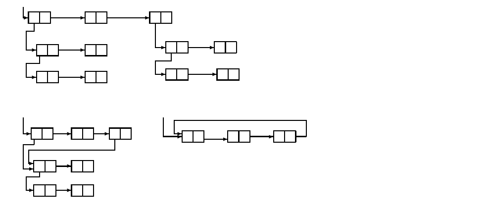

图 1 Figure 1

允许一个子结构出现在表结构中的多个位置，如图 1b；但不允许结构中存在环，如图 1c。原子符号在计算机中由一种特殊形式的表结构表示，称为该符号的关联表。第一个字的地址字段包含一个特殊常量，使程序能够识别这个字表示原子符号。第 4b 节将介绍关联表。

It is permitted for a substructure to occur in more than one place in a list structure, as in figure 1b, but it is not permitted for a structure to have cycles, as in figure 1c. An atomic symbol is represented in the computer by a list structure of special form called the association list of the symbol. The address field of the first word contains a special constant which enables the program to tell that this word represents an atomic symbol. We shall describe association lists in section 4b.

非原子的 S 表达式 x 由一个字表示，其地址字段和减量字段分别存放子表达式 car[x] 和 cdr[x] 的位置。如果用符号 A、B 等表示这些符号的关联表的位置，那么 S 表达式 ((A · B) · (C · (E · F))) 就由图 2a 的表结构表示。再看 S 表达式的列表形式，S 表达式 (A,(B,C),D) 是 (A · ((B · (C · NIL)) · (D · NIL))) 的缩写，它由图 2b 的表结构表示。

An S-expression x that is not atomic is represented by a word, the address and decrement parts of which contain the locations of the subexpressions car[x] and cdr[x], respectively. If we use the symbols A, B, etc. to denote the locations of the association list of these symbols, then the S-expression ((A · B) · (C · (E · F))) is represented by the list structure a of figure 2. Turning to the list form of S-expressions, we see that the S-expression (A, (B, C), D), which is an abbreviation for (A · ((B · (C · NIL)) · (D · NIL))), is represented by the list structure of figure 2b.

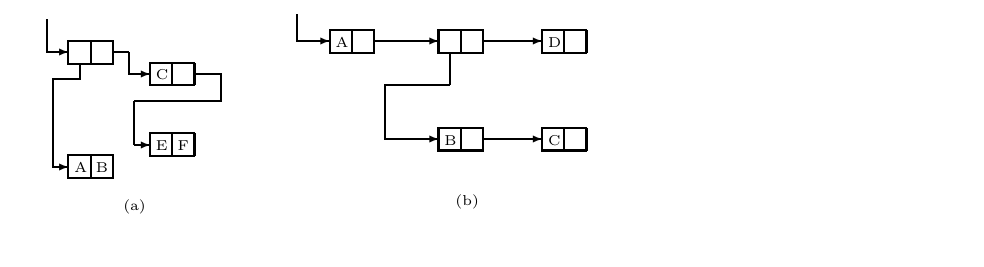

图 2 Figure 2

把表结构看作列表的表示时，可以看到：列表的每一项占据一个字的地址字段，该字的减量字段指向包含下一项的字，而最后一个字的减量字段中为 NIL。

When a list structure is regarded as representing a list, we see that each term of the list occupies the address part of a word, the decrement part of which points to the word containing the next term, while the last word has NIL in its decrement.

某个给定子表达式出现多次的表达式，可以有不止一种表示方式。子表达式的表结构是否重复，取决于程序执行的历史。无论子表达式是否重复，都不会影响程序在机器外部呈现的结果，但会影响时间和存储需求。例如，S 表达式 ((A·B)·(A·B)) 可以用图 3a 或图 3b 的任一种表结构表示。

An expression that has a given subexpression occurring more than once can be represented in more than one way. Whether the list structure for the subexpression is or is not repeated depends upon the history of the program. Whether or not a subexpression is repeated will make no difference in the results of a program as they appear outside the machine, although it will affect the time and storage requirements. For example, the S-expression ((A·B)·(A·B)) can be represented by either the list structure of figure 3a or 3b.

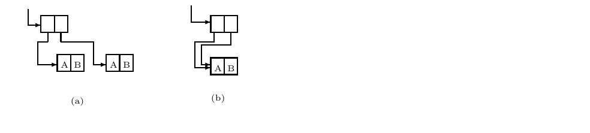

图 3 Figure 3

禁止循环表结构，本质上就是禁止一个表达式成为它自身的子表达式。在具有我们这种拓扑结构的世界中，这样的表达式不可能存在于纸面上。循环表结构在机器中会有一些好处，例如可以用来表示递归函数；但打印它们以及进行某些其他操作时存在困难，因此目前看来最好不使用它们。

The prohibition against circular list structures is essentially a prohibition against an expression being a subexpression of itself. Such an expression could not exist on paper in a world with our topology. Circular list structures would have some advantages in the machine, for example, for representing recursive functions, but difficulties in printing them, and in certain other operations, make it seem advisable not to use them for the present.

用表结构存储符号表达式有以下优点：

The advantages of list structures for the storage of symbolic expressions are:

1. 无法预先预测程序需要处理的表达式的大小，甚至无法预测其数量。因此，很难安排固定长度的存储块来容纳它们。

   The size and even the number of expressions with which the program will have to deal cannot be predicted in advance. Therefore, it is difficult to arrange blocks of storage of fixed length to contain them.
2. 存储单元不再需要时，可以放回空闲存储链表。即使只归还一个存储单元也有价值；但如果表达式按线性方式存储，就很难利用可能出现的、大小不规则的空闲存储块。

   Registers can be put back on the free-storage list when they are no longer needed. Even one register returned to the list is of value, but if expressions are stored linearly, it is difficult to make use of blocks of registers of odd sizes that may become available.
3. 一个表达式如果作为多个表达式的子表达式出现，只需在存储器中表示一次。

   An expression that occurs as a subexpression of several expressions need be represented in storage only once.

### b. 关联表⁶

### b. Association Lists6

在 LISP 编程系统中，符号的关联表所包含的内容，比前面各节所述数学系统所要求的更多。事实上，任何希望与该符号关联的信息都可以放入关联表。这些信息可以包括：打印名，即在机器外表示该符号的字母与数字串；若符号表示数字，则包括其数值；若符号在某种意义上充当另一 S 表达式的名字，则包括该 S 表达式；若符号表示一个具有机器语言子程序的函数，则包括该例程的位置。这意味着，机器系统中的原始实体，比前面数学系统各节所描述的更多。

In the LISP programming system we put more in the association list of a symbol than is required by the mathematical system described in the previous sections. In fact, any information that we desire to associate with the symbol may be put on the association list. This information may include: the print name, that is, the string of letters and digits which represents the symbol outside the machine; a numerical value if the symbol represents a number; another S-expression if the symbol, in some way, serves as a name for it; or the location of a routine if the symbol represents a function for which there is a machine-language subroutine. All this implies that in the machine system there are more primitive entities than have been described in the sections on the mathematical system.

目前只介绍如何在关联表中表示打印名，使程序在读入或打印时，能够在穿孔卡片、磁带或印刷页面上的信息，与机器内部的表结构之间建立对应。符号 DIFFERENTIATE 的关联表有一段如图 4 所示。这里 pname 是一个符号，表示该关联表所属符号的打印名结构挂接在关联表的下一个字上。图的第二行是一个由三个字组成的列表。每个字的地址字段都指向一个包含六个 6 位字符的字。最后一个字用一种不代表计算机可打印字符的 6 位组合补齐。请记住，IBM 704 的字长为 36 位，每个可打印字符用 6 位表示。包含字符信息的字的存在，意味着关联表本身并不表示 S 表达式，而且只有某些处理 S 表达式的函数在关联表内部有意义。

For the present, we shall only describe how print names are represented on association lists so that in reading or printing the program can establish a correspondence between information on punched cards, magnetic tape or printed page and the list structure inside the machine. The association list of the symbol DIFFERENTIATE has a segment of the form shown in figure 4. Here pname is a symbol that indicates that the structure for the print name of the symbol whose association list this is hanging from the next word on the association list. In the second row of the figure we have a list of three words. The address part of each of these words points to a Word containing six 6-bit characters. The last word is filled out with a 6-bit combination that does not represent a character printable by the computer. (Recall that the IBM 7O4 has a 36-bit word and that printable characters are each represented by 6 bits.) The presence of the words with character information means that the association lists do not themselves represent S-expressions, and that only some of the functions for dealing with S-expressions make sense within an association list.

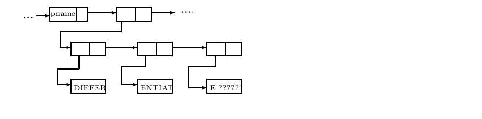

图 4 Figure 4

### c. 空闲存储链表

### c. Free-Storage List

在任意时刻，为表结构保留的内存中，只有一部分实际用于存储 S 表达式。其余存储单元，在我们的系统中最初约为 15,000 个，被组织成一个称为空闲存储链表的单一列表。程序中的一个特定寄存器 FREE，存放该列表第一个存储单元的位置。当需要一个字来构造额外的表结构时，就取走空闲存储链表中的第一个字，并把 FREE 寄存器中的数值改成链表中第二个字的位置。用户无需编程把存储单元归还到空闲存储链表。

At any given time only a part of the memory reserved for list structures will actually be in use for storing S-expressions. The remaining registers (in our system the number, initially, is approximately 15,000) are arranged in a single list called the free-storage list. A certain register, FREE, in the program contains the location of the first register in this list. When a word is required to form some additional list structure, the first word on the free-storage list is taken and the number in register FREE is changed to become the location of the second word on the free-storage list. No provision need be made for the user to program the return of registers to the free-storage list.

归还过程自动进行，大致如下。本文必须对这一过程作简化描述。程序中有一组固定的基址寄存器，包含程序可以访问的表结构的位置。当然，由于表结构会分支，因此可能涉及任意数量的存储单元。程序可访问的每个存储单元，都能够从一个或多个基址寄存器出发，通过一串 car 和 cdr 操作到达。当某个基址寄存器的内容改变时，它原来指向的存储单元，可能不再能从任何基址寄存器通过 car–cdr 链到达。这样的存储单元可以认为已被程序遗弃，因为任何可能的程序都无法再找到它的内容；因此，其内容已无意义，我们希望把它收回空闲存储链表。这个过程按如下方式发生。

This return takes place automatically, approximately as follows (it is necessary to give a simplified description of this process in this report): There is a fixed set of base registers in the program which contains the locations of list structures that are accessible to the program. Of course, because list structures branch, an arbitrary number of registers may be involved. Each register that is accessible to the program is accessible because it can be reached from one or more of the base registers by a chain of car and cdr operations. When the contents of a base register are changed, it may happen that the register to which the base register formerly pointed cannot be reached by a car −cdr chain from any base register. Such a register may be considered abandoned by the program because its contents can no longer be found by any possible program; hence its contents are no longer of interest, and so we would like to have it back on the free-storage list. This comes about in the following way.

在程序耗尽空闲存储之前，什么也不发生。当需要一个空闲存储单元，而空闲存储链表中已经没有剩余单元时，就启动一次回收<sup>7</sup>周期。

Nothing happens until the program runs out of free storage. When a free register is wanted, and there is none left on the free-storage list, a reclamation7 cycle starts.

首先，程序找出所有从基址寄存器可达的存储单元，并把它们的符号位改为负。具体做法是从每个基址寄存器出发，把所有能通过 car–cdr 链到达的存储单元的符号位改掉。如果过程中遇到一个符号位已经为负的存储单元，就认为它此前已经到达过。

First, the program finds all registers accessible from the base registers and makes their signs negative. This is accomplished by starting from each of the base registers and changing the sign of every register that can be reached from it by a car −cdr chain. If the program encounters a register in this process which already has a negative sign, it assumes that this register has already been reached.

所有可达存储单元的符号位都改变之后，程序遍历为表结构保留的内存区域，把上一步中符号位未改变的所有存储单元放回空闲存储链表，并把可达存储单元的符号位重新改为正。

After all of the accessible registers have had their signs changed, the program goes through the area of memory reserved for the storage of list structures and puts all the registers whose signs were not changed in the previous step back on the free-storage list, and makes the signs of the accessible registers positive again.

这一过程完全自动进行，因此比要求程序员自行跟踪和清除无用列表的系统更方便。其效率取决于可达列表不要接近耗尽全部可用内存。这是因为回收过程需要数秒钟；为了避免程序把大部分时间都花在回收上，每次回收至少应向空闲存储链表补充数千个存储单元。

This process, because it is entirely automatic, is more convenient for the programmer than a system in which he has to keep track of and erase unwanted lists. Its efficiency depends upon not coming close to exhausting the available memory with accessible lists. This is because the reclamation process requires several seconds to execute, and therefore must result in the addition of at least several thousand registers to the free-storage list if the program is not to spend most of its time in reclamation.

### d. 计算机中的初等 S 函数

### d. Elementary S-Functions in the Computer

下面介绍 atom、=、car、cdr 和 cons 在计算机中的表示。S 表达式通过表示它的字的位置，传递给表示函数的程序；程序也以同样形式给出 S 表达式结果。

We shall now describe the computer representations of atom, = , car, cdr, and cons. An S-expression is communicated to the program that represents a function as the location of the word representing it, and the programs give S-expression answers in the same form.

atom。如前所述，表示原子符号的字，其地址字段中包含一个特殊常量。atom 被编写为检查该字段的开放子程序。除非 M 表达式 atom[e] 作为条件表达式中的条件出现，否则测试结果会生成符号 T 或 F。对于条件表达式，则使用条件转移，不生成符号 T 或 F。

atom. As stated above, a word representing an atomic symbol has a special constant in its address part: atom is programmed as an open subroutine that tests this part. Unless the M-expression atom[e] occurs as a condition in a conditional expression, the symbol T or F is generated as the result of the test. In case of a conditional expression, a conditional transfer is used and the symbol T or F is not generated.

eq。eq[e;f] 的程序检验两个字的位置在数值上是否相等。之所以可行，是因为每个原子符号只有一个关联表。与 atom 一样，结果要么是条件转移，要么是符号 T 或 F 之一。

eq. The program for eq[e; f] involves testing for the numerical equality of the locations of the words. This works because each atomic symbol has only one association list. As with atom, the result is either a conditional transfer or one of the symbols T or F.

car。计算 car[x]，就是取得存储单元 x 的地址字段内容。这基本上由一条指令 CLA 0,i 完成：实参位于变址寄存器中，结果出现在累加器的地址字段。我们认为，函数从何处取得实参、把结果放到何处，都应在函数定义中规定；程序员或编译器负责插入必要的数据传送指令，使一次计算的结果处于下一次计算所需的位置。“car”是“存储单元地址字段的内容”的助记缩写。

car. Computing car[x] involves getting the contents of the address part of register x. This is essentially accomplished by the single instruction CLA 0, i, where the argument is in index register, and the result appears in the address part of the accumulator. (We take the view that the places from which a function takes its arguments and into which it puts its results are prescribed in the definition of the function, and it is the responsibility of the programmer or the compiler to insert the required datamoving instructions to get the results of one calculation in position for the next.) (“car” is a mnemonic for “contents of the address part of register.”)

cdr。cdr 的处理方式与 car 相同，只是结果出现在累加器的减量字段中。“cdr”表示“存储单元减量字段的内容”。

cdr. cdr is handled in the same way as car, except that the result appears in the decrement part of the accumulator (“cdr” stands for “contents of the decrement part of register.”)

cons。cons[x;y] 的值必须是某个存储单元的位置，该单元的地址字段和减量字段分别包含 x 和 y。计算机中可能不存在这样的单元；即使存在，查找它也很耗时。实际做法是，从空闲存储链表中取出第一个可用单元，分别把 x 和 y 放入其地址字段和减量字段，并把所取单元的位置作为函数值。“cons”是“construct”（构造）的缩写。

cons. The value of cons[x; y] must be the location of a register that has x and y in its address and decrement parts, respectively. There may not be such a register in the computer and, even if there were, it would be time-consuming to find it. Actually, what we do is to take the first available register from the free-storage list, put x and y in the address and decrement parts, respectively, and make the value of the function the location of the register taken. (“cons” is an abbreviation for “construct.”)

空闲存储链表耗尽时，由 cons 子程序启动回收。在目前使用的系统版本中，cons 由封闭子程序表示；在编译版本中，cons 是开放的。

It is the subroutine for cons that initiates the reclamation when the free-storage list is exhausted. In the version of the system that is used at present cons is represented by a closed subroutine. In the compiled version, cons is open.

### e. 用程序表示 S 函数

### e. Representation of S-Functions by Programs

无论手工编译还是使用编译器程序，由 car、cdr 和 cons 复合而成的函数都很容易编译。条件表达式也没有什么困难，只需保证编译后只计算必要的 p 和 e。不过，编译递归函数时会出现问题。

The compilation of functions that are compositions of car, cdr, and cons, either by hand or by a compiler program, is straightforward. Conditional expressions give no trouble except that they must be so compiled that only the p’s and e’s that are required are computed. However, problems arise in the compilation of recursive functions.

一般而言，稍后会讨论一种例外，递归函数的例程会把自身当作子程序使用。例如，subst[x;y;z] 的程序使用自身作为子程序，计算对子表达式 car[z] 和 cdr[z] 进行替换的结果。计算 subst[x;y;cdr[z]] 时，必须把先前计算 subst[x;y;car[z]] 的结果保存在临时存储单元中。然而，subst 在计算 subst[x;y;cdr[z]] 时，可能也需要使用同一个存储单元。这个潜在冲突由使用公共下推表<sup>8</sup>的 SAVE 和 UNSAVE 例程解决。进入递归函数例程时，先进入 SAVE 例程，请求保存一组给定的连续存储单元。为此保留了一块称为公共下推表的存储区。SAVE 例程有一个索引，指出下推表中已有多少存储单元正在使用。它把需要保存的单元内容移到下推表中最前面的未用单元，推进索引，然后返回调用程序。调用程序随后可以自由地把这些单元用作临时存储。例程退出前调用 UNSAVE，从下推表恢复临时单元的内容，并回退索引。用编程术语来说，这些约定使递归子程序对临时存储单元具有透明性。

In general (we shall discuss an exception), the routine for a recursive function uses itself as a subroutine. For example, the program for subst[x; y; z] uses itself as a subroutine to evaluate the result of substituting into the subexpressions car[z] and cdr[z]. While subst[x; y; cdr[z]] is being evaluated, the result of the previous evaluation of subst[x; y; car[z]] must be saved in a temporary storage register. However, subst may need the same register for evaluating subst[x; y; cdr[z]]. This possible conflict is resolved by the SAVE and UN- SAVE routines that use the public push-down list 8. The SAVE routine is entered at the beginning of the routine for the recursive function with a request to save a given set of consecutive registers. A block of registers called the public push-down list is reserved for this purpose. The SAVE routine has an index that tells it how many registers in the push-down list are already in use. It moves the contents of the registers which are to be saved to the first unused registers in the push-down list, advances the index of the list, and returns to the program from which control came. This program may then freely use these registers for temporary storage. Before the routine exits it uses UNSAVE, which restores the contents of the temporary registers from the push-down list and moves back the index of this list. The result of these conventions is described, in programming terminology, by saying that the recursive subroutine is transparent to the temporary storage registers.

### f. LISP 编程系统的状态，1960 年 2 月

### f. Status of the LISP Programming System (February 1960)

程序 APPLY 已嵌入 LISP 编程系统，系统具有以下特性：

The program APPLY has been imbedded in the LISP programming system which has the following features:

1. 程序员可以用 S 表达式定义任意数量的 S 函数。这些函数可以互相引用，也可以引用某些由机器语言程序表示的 S 函数。

   The programmer may define any number of S-functions by S-expressions. these functions may refer to each other or to certain S-functions represented by machine language program.
2. 可以计算已定义函数的值。

   The values of defined functions may be computed.
3. 可以直接或通过磁带读入和打印 S 表达式。

   S-expressions may be read and printed (directly or via magnetic tape).
4. 包含一些错误诊断和选择性跟踪功能。

   Some error diagnostic and selective tracing facilities are included.
5. 程序员可以选择一些 S 函数，将其编译成机器语言程序并放入磁芯存储器。编译后函数的求值速度约为解释执行时的 60 倍。编译速度足够快，因此不必把编译后的程序打孔保存，以供将来使用。

   The programmer may have selected S-functions compiled into machine language programs put into the core memory. Values of compiled functions are computed about 60 times as fast as they would if interpreted. Compilation is fast enough so that it is not necessary to punch compiled program for future use.
6. 一种“程序特性”允许编写包含 ALGOL 风格赋值语句和 go to 语句的程序。

   A “program feature” allows programs containing assignment and go to statements in the style of ALGOL.
7. 系统可以进行浮点数计算，但效率不高。

   Computation with floating point numbers is possible in the system, but this is inefficient.
8. 正在编写程序员手册。

   A programmer’s manual is being prepared.

LISP 编程系统适用于这样一类计算：其数据可以方便地表示为符号表达式，并允许同类表达式作为子表达式。IBM 709 版本的系统正在准备中。

The LISP programming system is appropriate for computations where the data can conveniently be represented as symbolic expressions allowing expressions of the same kind as subexpressions. A version of the system for the IBM 709 is being prepared.

## 5 符号表达式函数的另一种形式体系

## 5 Another Formalism for Functions of Symbolic Expressions

有多种定义符号表达式函数的方法，与我们采用的系统十分相似。每种方法都涉及三个基本函数、条件表达式和递归函数定义，但对应于 S 表达式的表达式类不同，函数的精确定义也不同。下面介绍其中一个变体，称为线性 LISP。

There are a number of ways of defining functions of symbolic expressions which are quite similar to the system we have adopted. Each of them involves three basic functions, conditional expressions, and recursive function definitions, but the class of expressions corresponding to S-expressions is different, and so are the precise definitions of the functions. We shall describe one of these variants called linear LISP.

L 表达式定义如下：

The L-expressions are defined as follows:

1. 规定一个有限的允许字符表。

   A finite list of characters is admitted.
2. 由允许字符构成的任意字符串都是 L 表达式。其中包括以 Λ 表示的空字符串。

   Any string of admitted characters in an L-expression. This includes the null string denoted by Λ.

字符串上有三个函数：

There are three functions of strings:

1. first[x] 是字符串 x 的第一个字符。

   first[x] is the first character of the string x.

   first[Λ] 未定义。例如：first[ABC] = A。

   first[Λ] is undefined. For example: first[ABC] = A
2. rest[x] 是从字符串中删除第一个字符后剩余的字符串。

   rest[x] is the string of characters which remains when the first character of the string is deleted.

   rest[Λ] 未定义。例如：rest[ABC] = BC。

   rest[Λ] is undefined. For example: rest[ABC] = BC.
3. combine[x;y] 是把字符 x 加到字符串 y 前面所形成的字符串。例如：combine[A;BC] = ABC。

   combine[x; y] is the string formed by prefixing the character x to the string y. For example: combine[A; BC] = ABC

字符串上有三个谓词：

There are three predicates on strings:

1. char[x]：x 是单个字符。

   char[x], x is a single character.
2. null[x]：x 是空字符串。

   null[x], x is the null string.
3. x = y，在 x 和 y 都是字符时有定义。

   x = y, defined for x and y characters.

线性 LISP 的优点是，不像 LISP 中的圆括号、点和逗号那样，任何字符都没有特殊作用。这使它能够对所有可以线性书写的表达式进行计算。缺点是，提取子表达式是一项相当复杂的操作，而不是初等操作。在 线性 LISP 中编写对应于 LISP 基本函数的函数并不困难，因此从数学上说，线性 LISP 包含 LISP。事实证明，在 线性 LISP 中编写更复杂的操作时，这也是最方便的方法。不过，如果这些函数要用计算机例程表示，LISP 本质上更快。

The advantage of linear LISP is that no characters are given special roles, as are parentheses, dots, and commas in LISP. This permits computations with all expressions that can be written linearly. The disadvantage of linear LISP is that the extraction of subexpressions is a fairly involved, rather than an elementary, operation. It is not hard to write, in linear LISP, functions that correspond to the basic functions of LISP, so that, mathematically, linear LISP includes LISP. This turns out to be the most convenient way of programming, in linear LISP, the more complicated manipulations. However, if the functions are to be represented by computer routines, LISP is essentially faster.

## 6 流程图与递归

## 6 Flowcharts and Recursion

通常形式的计算机程序和递归函数定义，在计算能力上都是通用的，因此展示它们之间的关系很有意义。本报告此前的内容讨论了如何把递归符号函数翻译成计算机程序。本节说明如何反过来做，至少在原理上如此。

Since both the usual form of computer program and recursive function definitions are universal computationally, it is interesting to display the relation between them. The translation of recursive symbolic functions into computer programs was the subject of the rest of this report. In this section we show how to go the other way, at least in principle.

计算过程中，机器在任意时刻的状态由若干变量的值给出。把这些变量组合成向量 ξ。考虑一个只有一个入口和一个出口的程序块。它定义了某个把一种机器配置变成另一种配置的函数 f，而且本质上也由该函数定义；即 f 具有 ξ′ = f(ξ) 的形式。我们把 f 称为该程序块的关联函数。现在用决策元素 π 把若干这样的程序块组合成程序，决策元素在每个块完成后决定接下来进入哪个块。同时，仍要求整个程序只有一个入口和一个出口。

The state of the machine at any time during a computation is given by the values of a number of variables. Let these variables be combined into a vector ξ. Consider a program block with one entrance and one exit. It defines and is essentially defined by a certain function f that takes one machine configuration into another, that is, f has the form ξ′ = f(ξ). Let us call f the associated function of the program block. Now let a number of such blocks be combined into a program by decision elements π that decide after each block is completed which block will be entered next. Nevertheless, let the whole program still have one entrance and one exit.

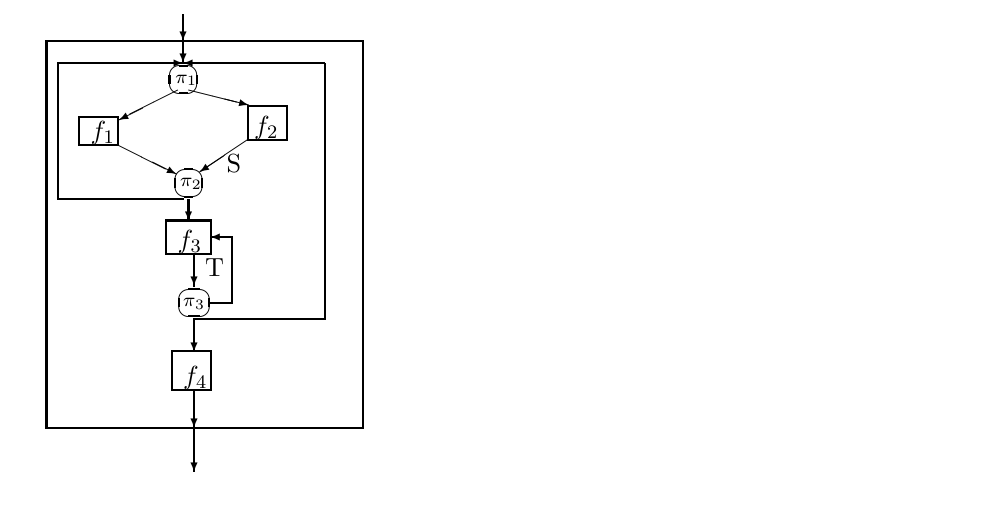

图 5 Figure 5

以图 5 的流程图为例。函数 r[ξ] 给出向量 ξ 从整个块的入口到出口的变换。我们把它与函数 s(ξ) 和 t[ξ] 一起定义，后二者分别给出 ξ 从点 S 和点 T 到出口所经历的变换。规定如下：

We give as an example the flowcart of figure 5. Let us describe the function r[ξ] that gives the transformation of the vector ξ between entrance and exit of the whole block. We shall define it in conjunction with the functions s(ξ), and t[ξ], which give the transformations that ξ undergoes between the points S and T, respectively, and the exit. We have

$r[ξ]=[π11[ξ]→S[f1[ξ]];T→S[f2[ξ]]]S[ξ]=[π21[ξ]→r[ξ];T→t[f3[ξ]]]t[ξ]=[π3I[ξ]→f4[ξ];π32[ξ]→r[ξ];T→t[f3[ξ]]]$

给定一个单入口、单出口的流程图，很容易根据各计算块对应的函数和分支谓词，写出描述状态向量从入口到出口变换的递归函数。一般过程如下。

Given a flowchart with a single entrance and a single exit, it is easy to write down the recursive function that gives the transformation of the state vector from entrance to exit in terms of the corresponding functions for the computation blocks and the predicates of the branch. In general, we proceed as follows.

在图 6 中，设 β 是一个 n 路分支点，f₁，……，fₙ 是通向分支点 β₁、β₂，……，βₙ 的计算。设 φ 是描述 ξ 从 β 到流程图出口之间变换的函数，φ₁，……，φₙ 分别是 β₁，……，βₙ 对应的函数。于是写作：

In figure 6, let β be an n-way branch point, and let f<sub>1</sub>, · · ·, f<sub>n</sub> be the computations leading to branch points β1, β2, · · ·, βn. Let φ be the function that transforms ξ between β and the exit of the chart, and let φ1, · · · , φn be the corresponding functions for β1, · · ·, βn. We then write

$φ[ξ]=[p1[ξ]→φ1[f1[ξ]];···;pn[ξ]→φn[ξ]]]$

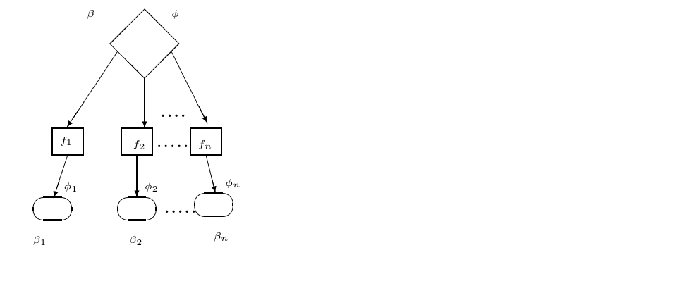

图 6 Figure 6

## 7 致谢

## 7 Acknowledgments

N. Rochester 注意到 λ 记法不足以为递归函数命名，并发现了一种不同于本文所用 label 方案的替代方法。IBM 公司的 C. Gerberick 和 H. L. Gelernter 在开发另一套编程系统时，发明了使 cons 能与其他函数复合的子程序形式。LISP 编程系统由一个小组开发，成员包括 R. Brayton、D. Edwards、P. Fox、L. Hodes、D. Luckham、K. Maling、J. McCarthy、D. Park 和 S. Russell。

The inadequacy of the λ-notation for naming recursive functions was noticed by N. Rochester, and he discovered an alternative to the solution involving label which has been used here. The form of subroutine for cons which permits its composition with other functions was invented, in connection with another programming system, by C. Gerberick and H. L. Gelernter, of IBM Corporation. The LlSP programming system was developed by a group including R. Brayton, D. Edwards, P. Fox, L. Hodes, D. Luckham, K. Maling, J. McCarthy, D. Park, S. Russell.

小组得到麻省理工学院计算中心和麻省理工学院电子学研究实验室的支持。后者的部分经费来自美国陆军通信兵团、美国空军科学研究办公室及航空研究与发展司令部，以及美国海军海军研究办公室。作者还感谢 Alfred P. Sloan 基金会给予的个人经费支持。

The group was supported by the M.I.T. Computation Center, and by the M.I.T. Research Laboratory of Electronics (which is supported in part by the the U.S. Army (Signal Corps), the U.S. Air Force (Office of Scientific Research, Air Research and Development Command), and the U.S. Navy (Office of Naval Research)). The author also wishes to acknowledge the personal financial support of the Alfred P. Sloan Foundation.

## 参考文献

## REFERENCES

1. J. McCarthy，《具有常识的程序》。1958 年 11 月 24–27 日在英国特丁顿国家物理实验室“思维过程机械化”研讨会上宣读。由英国皇家文书局出版于该研讨会论文集。

   J. McCARTHY, Programs with common sense, Paper presented at the Symposium on the Mechanization of Thought Processes, National Physical Laboratory, Teddington, England, Nov. 24-27, 1958. (Published in Proceedings of the Symposium by H. M. Stationery Office).
2. A. Newell 和 J. C. Shaw，《逻辑理论机的编程》，《西部联合计算机会议论文集》，1957 年 2 月。

   A. NEWELL AND J. C. SHAW, Programming the logic theory machine, Proc. Western Joint Computer Conference, Feb. 1957.
3. A. Church，《λ 转换演算》，普林斯顿大学出版社，新泽西州普林斯顿，1941 年。

   A. CHURCH, The Calculi of Lambda-Conversion (Princeton University Press, Princeton, N. J., 1941).
4. 《FORTRAN 程序员参考手册》，IBM 公司，纽约，1956 年 10 月 15 日。

   FORTRAN Programmer’s Reference Manual, IBM Corporation, New York, Oct. 15, 1956.
5. A. J. Perlis 和 K. Samelson，《国际代数语言》，初步报告，《ACM 通讯》，1958 年 12 月。

   A. J. PERLIS AND K. SAMELS0N, International algebraic language, Preliminary Report, Comm. Assoc. Comp. Mach., Dec. 1958.

## 脚注与后补注

## Footnotes and Later Notes

1. *. 本文的 LaTeX 排版工作，部分由 ARPA（ONR）授予斯坦福大学的 N00014-94-1-0775 号项目资助。John McCarthy 自 1962 年起在该校任职。本文根据 1960 年 4 月的《ACM 通讯》复制，仅对记法作了少量更改。如需准确的原始排印形式，请查阅该刊。现地址：John McCarthy，计算机科学系，斯坦福大学，加利福尼亚州斯坦福 94305。电子邮件：jmc@cs.stanford.edu；网址：http://www-formal.stanford.edu/jmc/

   *. Putting this paper in LaTeX partly supported by ARPA (ONR) grant N00014-94-1-0775 to Stanford University where John McCarthy has been since 1962. Copied with minor notational changes from CACM, April 1960. If you want the exact typography, look there. Current address, John McCarthy, Computer Science Department, Stanford, CA 94305, (email: jmc@cs.stanford.edu), (URL: http://www-formal.stanford.edu/jmc/ )
2. 1. 参见 Kleene。

   1. reference Kleene
3. 2. 我曾向《ACM 通讯》关于 Algol 60 应包含哪些内容的论坛提交过一项条件表达式提案。由于篇幅很短，编辑把它降格为致编辑的信；《ACM 通讯》后来为此道歉。这里给出的记法未被 Algol 60 接受，因为当时已决定 Algol 60 不允许采用新的数学记法，所有新内容都必须用英语表示。Algol 60 所采用的 if … then … else 是 John Backus 建议的。

   2. I sent a proposal for conditional expressions to a CACM forum on what should be included in Algol 60. Because the item was short, the editor demoted it to a letter to the editor, for which CACM subsequently apologized. The notation given here was rejected for Algol 60, because it had been decided that no new mathematical notation should be allowed in Algol 60, and everything new had to be English. The if … then … else that Algol 60 adopted was suggested by John Backus.
4. 3. 1995 年补注：符号内部可以允许空格，是因为当时列表元素之间用逗号分隔。

   3. 1995 remark: Imbedded blanks could be allowed within symbols, because lists were then written with commas between elements.
5. 4. 1995 年补注：SAIL 以及后来的 Lisp 机器提供了更多字符。遗憾的是，世界后来又退回到较差的字符集，尽管还没有退到本文在 1959 年初写作时的程度。

   4. 1995: More characters were made available on SAIL and later on the Lisp machines. Alas, the world went back to inferior character sets again, though not as far back as when this paper was written in early 1959.
6. 5. 1995 年补注：这个版本并不完全正确。Herbert Stoyan 的《设计者对设计的影响》比较了这个版本与其他 eval 版本，包括实际实现并调试过的版本。该文收入 Vladimir Lifschitz 编《人工智能与计算的数学理论：献给 John McCarthy 的论文集》，Academic Press，1991 年。

   5. 1995: This version isn’t quite right. A comparison of this and other versions of eval including what was actually implemented (and debugged) is given in “The Influence of the Designer on the Design” by Herbert Stoyan and included in Artificial Intelligence and Mathematical Theory of Computation: Papers in Honor of John McCarthy, Vladimir Lifschitz (ed.), Academic Press, 1991.
7. 6. 1995 年补注：这些后来称为属性表。

   6. 1995: These were later called property lists.
8. 7. 我们当时已经把这个过程称为“垃圾回收”，但我想，我在论文中不敢使用这个说法，或者是电子学研究实验室负责语法的女士们不让我用。

   7. We already called this process “garbage collection”, but I guess I chickened out of using it in the paper, or else the Research Laboratory of Electronics grammar ladies wouldn’t let me.
9. 8. 1995 年补注：现在称为栈。

   8. 1995: now called a stack